# Worksheet 4: Data Visualization

### Faceting

Unlike the previous exmaples, `facet_wrap` is not a geom. It splits the chart window in several small parts (a grid), and displays a similar chart in each section. Each section usually shows the same graph for a specific group of the dataset. For example, remember the line chart above that graphed the number of locations in the `gayguides` data across each year? We can facet that by state to see the number of locations in each state in each year.

```r
gg.year <- gayguides %>% filter(state == "SC" | state == "NC" | state == "GA") %>% group_by(state, Year) %>% summarize(count = n())
```

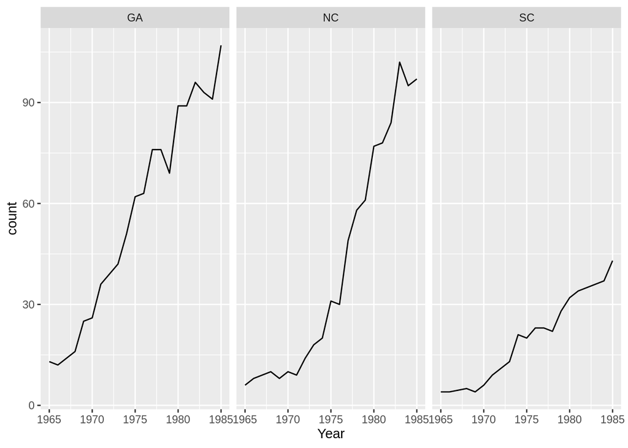

```r
ggplot(gg.year, aes(x = Year, y = count)) +
  geom_line() + facet_wrap(~state)
```

14. Using the state recreation data, can you create a chart that outlines the total expenditures in South Carolina by city?

```r
data(recreational.data) #load the data
```

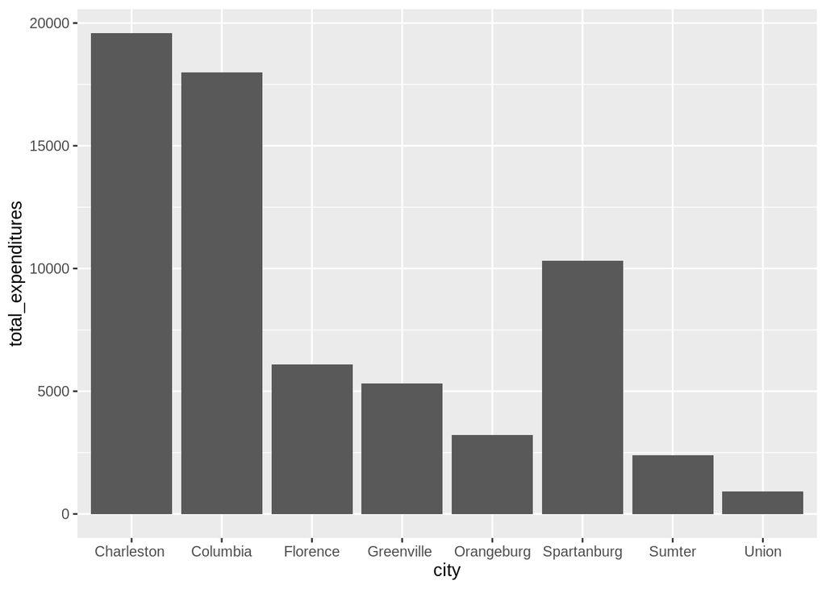

```r
sc.rec <- recreational.data %>% #name it
  filter(state == "SC") %>%
  select(state, city, total_expenditures) %>% #select state and total expenditures
  group_by(total_expenditures, city)

ggplot(sc.rec, aes(x = city, y = total_expenditures)) +
  geom_col()
```

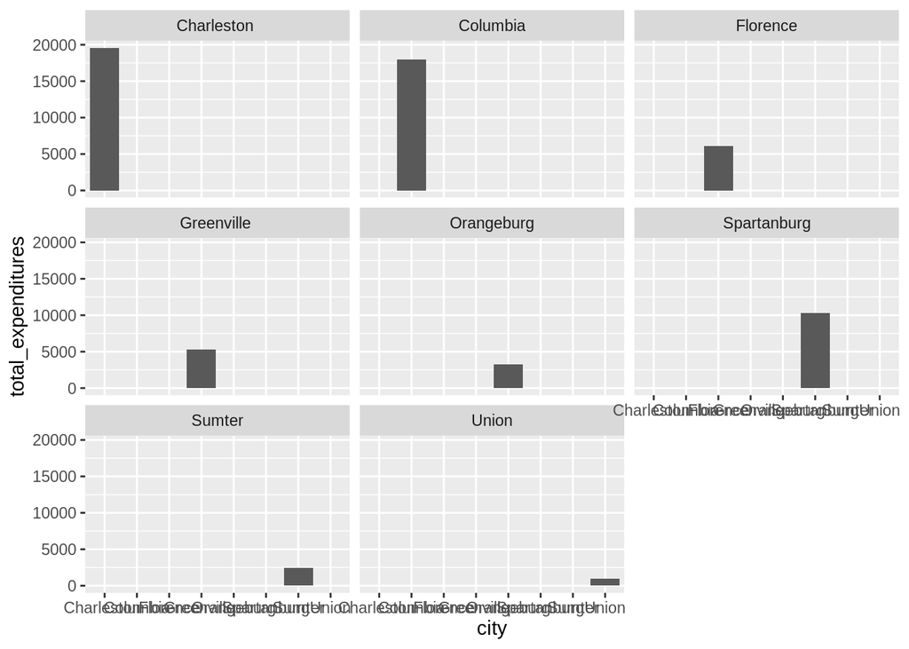

```r
ggplot(sc.rec, aes(x = city, y = total_expenditures)) +
  geom_col() + facet_wrap(~city) #forgot the facet wrap
```

15. Using the gayguides data can you select 5 types of locations and chart the number of each type between 1965 and 1980?

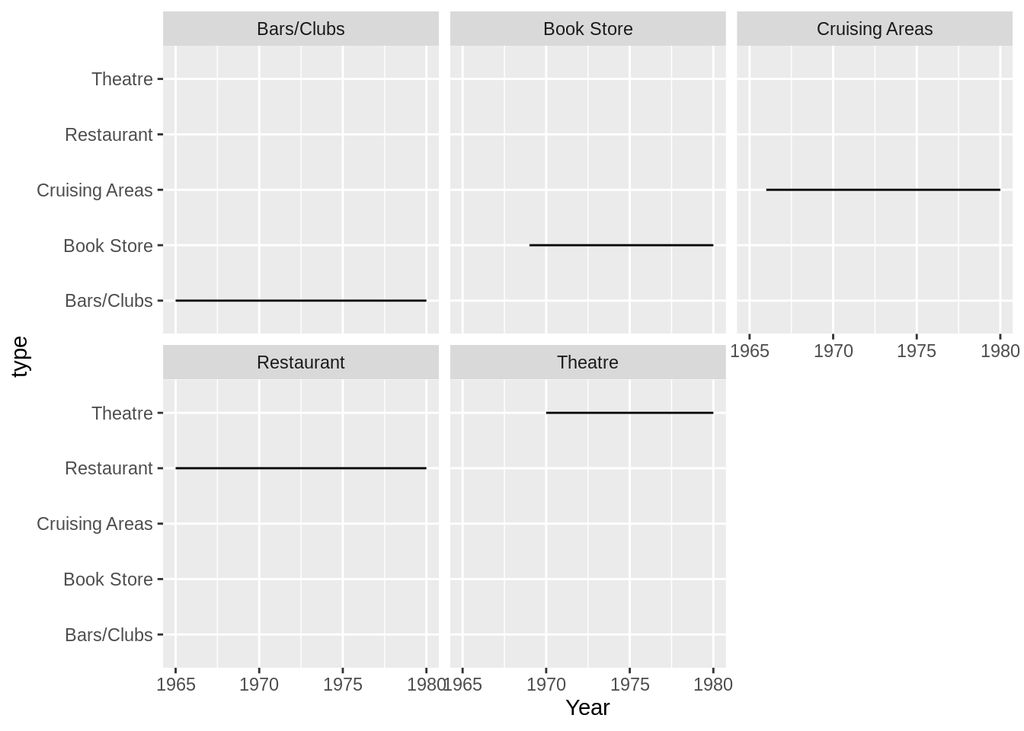

```r
location.types <- gayguides %>% #create variable
  filter(Year >= 1965 & Year <= 1980) %>%
  filter(type == "Book Store" | type == "Cruising Areas" | type == "Bars/Clubs" | type == "Restaurant" | type == "Theatre") %>% #filter out a few different types
  group_by(Year, type) %>%
  summarize(count = n())
ggplot(location.types, aes(x = Year, y = type)) +
  geom_line() + facet_wrap(~type)
```

```r
#I tried to facet wrap Year before type and it was not clear at all what the data was.
#type is much clearer.
```

16. Using this recreation dataset from last week, can you find the average number of volunteer and paid workers over time?

### Practice

In the slots below use the datasets for class (or a dataset of your choice) to create a plot. The plot you create in each of these three examples should try to make some kind of historical observation. After you finish creating the plot, write a short paragraph that explains what kind of observation you were trying to make and what your plot demonstrates.

17. Plot 1
18. Plot 1 explanation:

> I couldn’t get this to work, but I wanted to see the average length of stay at the Almshouse based on the years when people were admitted and when they were discharged.

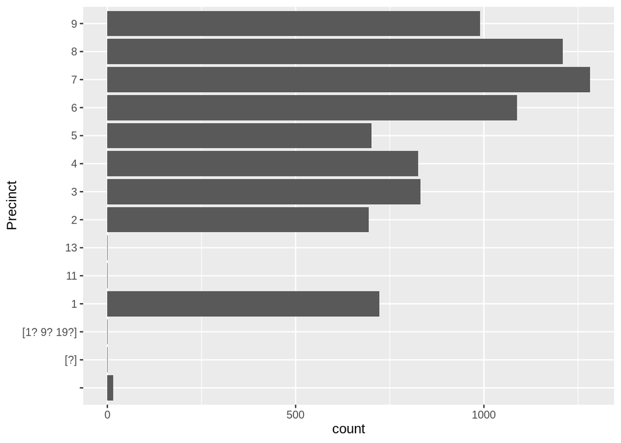

```r
data("BostonWomenVoters")

women.data <- BostonWomenVoters %>%
  select(Precinct, Name, Age, Country.of.Birth) %>%
  filter(Country.of.Birth == "United States") %>%
  na.omit() %>%
  group_by(Precinct, Age) %>%
  reframe(Age)


ggplot(women.data) +
    geom_bar(aes(y = Precinct))
```

20. Plot 2 explanation:

> I would like to see the average age of women at each precinct from the Boston Women Voter dataset. I’m just not sure how to get that data looking clean and easy to read. From what it’s showing, it looks like there was a large number of women voters at Precinct 7, followed by Precinct 8 and then 6.
21. Plot 3. For this one, try a different kind of plot. [Check out a useful gallery here.](https://github.com/regan008/DigitalMethodsData/blob/main/raw/RecreationData-Wide.csv) (For this week, avoid choosing a map. We’ll talk more about maps and geographic data over the next two weeks.)
22. Plot 3 explanation: >